# RF_latent_variable

Jineta Banerjee

05 November, 2019

## 0.1 Introduction

This document describes training a random forest model using laten variables generated by transfer learning approaches. We are using the latent variables found in pNF and MPNST data to train the forest to find the most important classifiers for these two tumor types. We chose to train a random forest classifier to identify NF tumortypes for the following features of the model : * robustness to high dimensinality data * ability to handle unbalanced classes * robustness to outliers and non-linear data * quick training /prediction speeds * low bias and moderate variance

Our goal is to find important latent variables that classify the various tumorTypes. We will then inspect the classifying features to find meaningful genesets that distinguish between two tumortypes.

Tumortypes represented in the data: * Plexiform Neurofibroma * MPNST

## 0.2 Partitioning the data into training and testing set:

The resulting filtered dataset was then split into 75% training and 25% testing dataset. The function *createDataPartition* is used to create balanced splits of the data. Since the *tumorType* argument to this function is a factor, the random sampling occurs within each class and should preserve the overall class distribution of the data.

## 0.3 Model training and Crossvalidation :

We then trained the model on the training dataset using iterative *mtrys* and 500 trees. The model was crossvalidated using 10-fold corssvalidation technique. The details of the model are described below.

```
## [1] " Check the fit of the model"
```

```
## Random Forest
##
##  51 samples
## 962 predictors
##   2 classes: 'Plexiform Neurofibroma', 'Malignant Peripheral Nerve Sheath Tumor'
##
## No pre-processing
## Resampling: Cross-Validated (10 fold, repeated 10 times)
## Summary of sample sizes: 46, 46, 45, 46, 46, 45, ...
## Resampling results across tuning parameters:
##
##   mtry  Accuracy   Kappa
##     2   0.9110000  0.6414286
##    43   0.9216667  0.6814286
##   961   0.8871667  0.5705844
##
## Accuracy was used to select the optimal model using the largest value.
## The final value used for the model was mtry = 43.
```

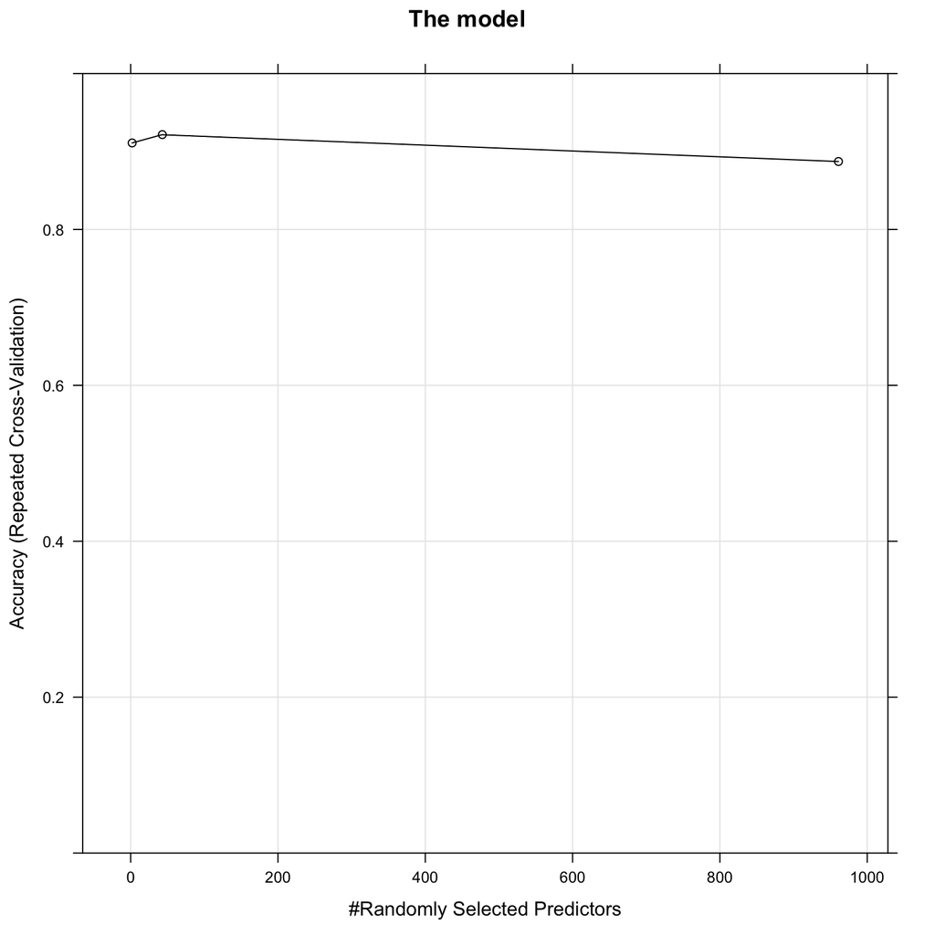

```
## [1] "Check the sizes of trees in the model"
```

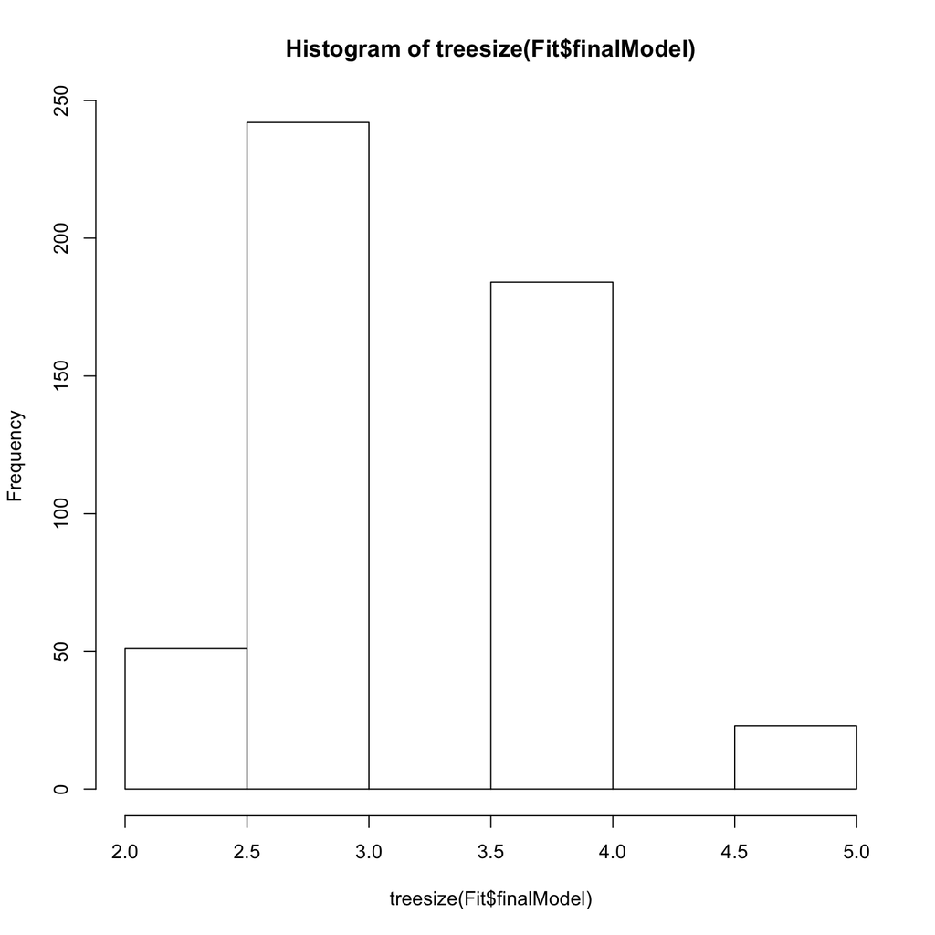

```
## [1] "Check the clustering of the samples accoriding to the model"
```

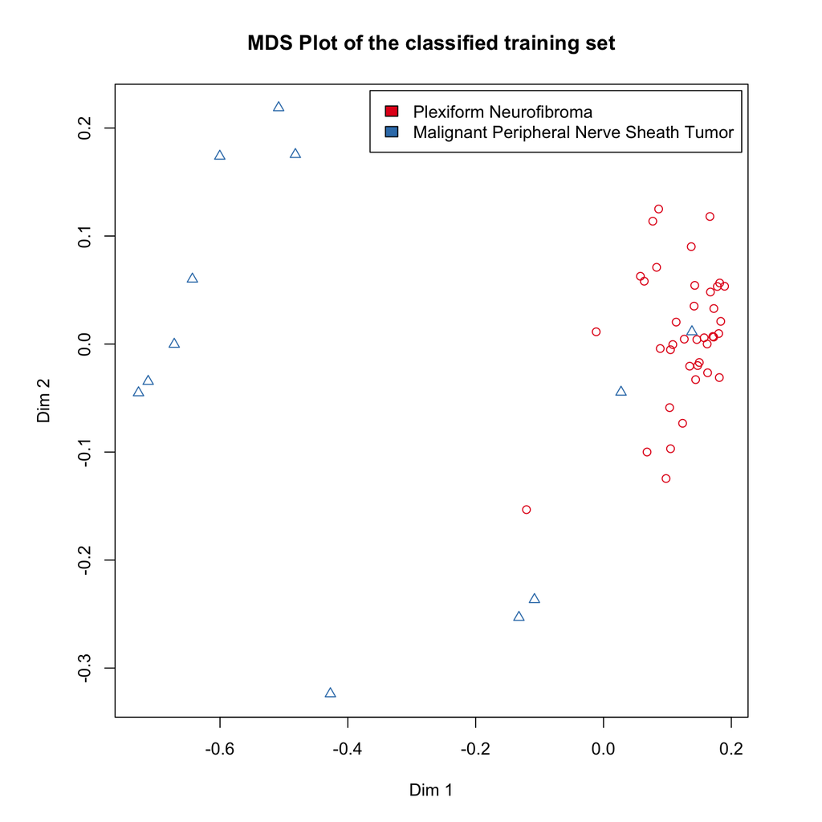

## 0.4 Check the quality of prediction

The confusion matrix of the prediction using the model is given below.

```
##                                          Reference
## Prediction                                Plexiform Neurofibroma
##   Plexiform Neurofibroma                                      13
##   Malignant Peripheral Nerve Sheath Tumor                      0
##                                          Reference
## Prediction                                Malignant Peripheral Nerve Sheath Tumor
##   Plexiform Neurofibroma                                                        1
##   Malignant Peripheral Nerve Sheath Tumor                                       3
```

## 0.5 Visualizing the predictors of the model:

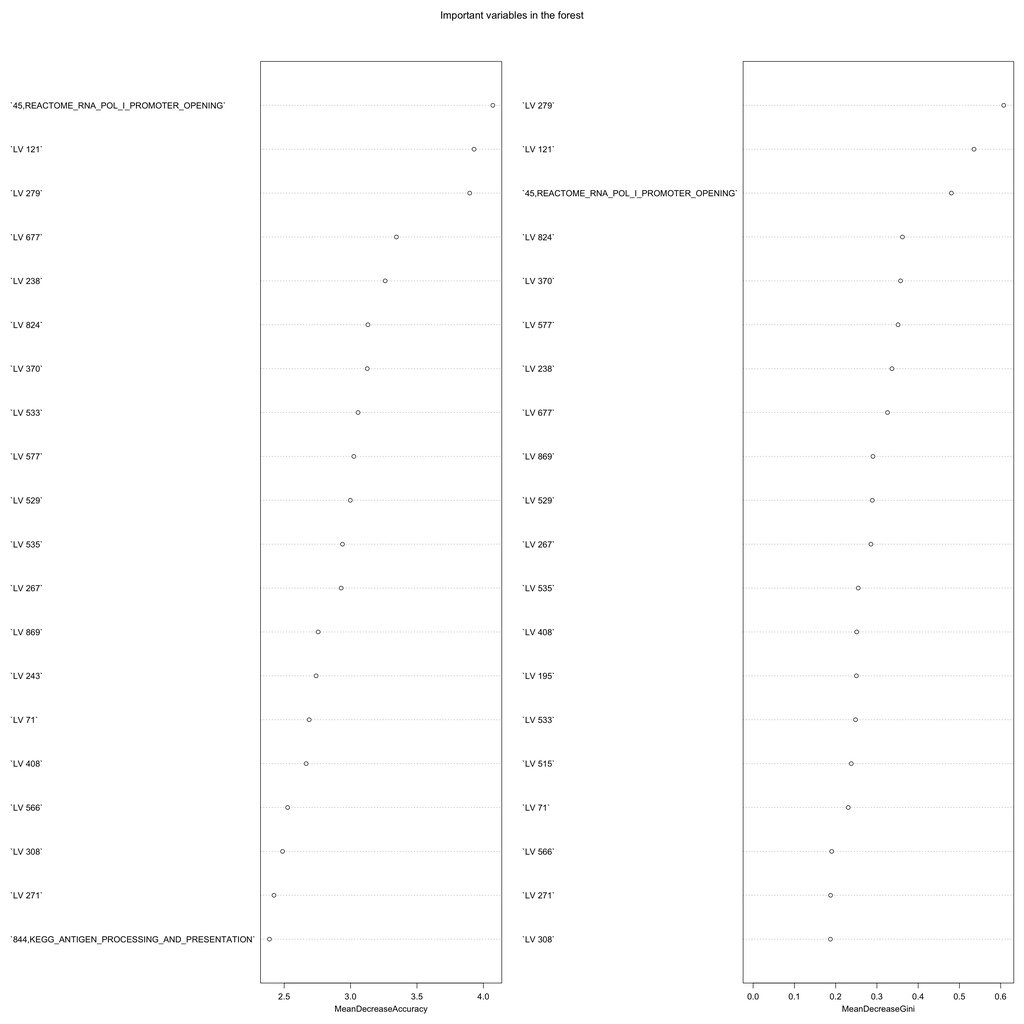

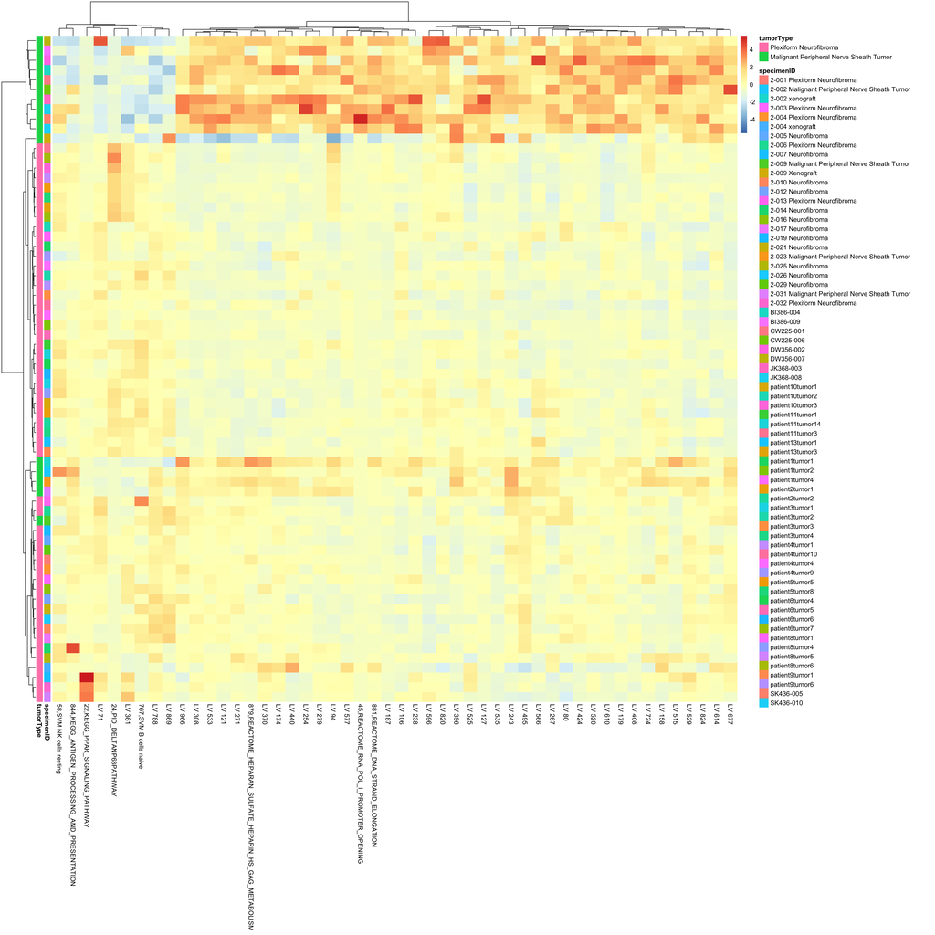